# Exploring an Extension of Predicting the Present with Google Trends by Improving Baseline Feature Selection

Hasanat Jahan & Tamar Yastrab

6/24/2020

# In Critique of “Predicting the Present with Google Trends” by Hyunyoung Choi and Hal Varian

## Question

Question: Can we use a better model- with either Census Data or additional public datasets- that would beat the trends model?

Subtext: One weakness of the paper “Predicting the Present with Google Trends” is that in an attempt to show the strength of the trends data, Choi and Varian use an overly simplified model for the baseline data that is easy to beat. We want to build a better model using only baseline data to demonstrate that even if the trends data is helpful, it is at best as good as more rigorous baseline models.

Additional features to consider: - Interest Data - Crude Oil Price - Consumer Price Index

Import the necessary libraries

```r
library(tidyverse)
library(scales)
library(modelr)
library(lubridate)
library(dplyr)
library(readr)
```

### Reproduce the findings based on author-provided data

Read in the given data

```r
mvp <- read.csv("merged.csv", header=T) %>%
    mutate(ymd = as.Date(Period, "%Y/%m/%d"))

mvp_lag <- mvp %>%
  select(-suvs, -insurance) %>%
  mutate(last_month = lag(sales), last_year = lag(sales, 12)) %>%
  mutate(row_num = row_number()) %>%
  mutate(log_sales = log(sales)) %>%
  mutate(ymd = as.Date(Period, "%Y/%m/%d"))
```

## Exploratory Data Analysis

As we do not have direct data for consumer price index from the census, another likely indicator of how much people are spending and willing to spend on buying a car can be the retail value of the month. Our intuition is that if people are spending more money, they have more money in their hand to spend and they are more likely buy an automobile they might have needed.

From the census data we can start looking at the monthly retail trade

| ymd | Retail |
| --- | --- |
| 2004-01-01 | 252818 |
| 2004-02-01 | 253689 |
| 2004-03-01 | 287944 |
| 2004-04-01 | 284325 |
| 2004-05-01 | 296253 |
| 2004-06-01 | 289664 |
| 2004-07-01 | 294875 |
| 2004-08-01 | 294133 |
| 2004-09-01 | 282974 |
| 2004-10-01 | 287468 |

[output cut: 86 more lines]

After loading in that data, let’s load in the census data for autos from years 2004-2011.

```r
# this takes the census data auto sales
real_base_mvp <-
  read.csv("real_base_autos.csv") %>%
  mutate(ymd2 = paste(Period, "-01", sep="")) %>%
  mutate(ymd = as.Date(ymd2, "%b-%y-%d")) %>%
  mutate(last_month = lag(Value), last_year = lag(Value, 12)) %>%
  mutate(row_num = row_number()) %>%
  mutate(log_sales = log(Value)) %>%
  select(ymd, last_month, last_year, Value, log_sales, row_num)

real_base_mvp
```

| ymd | last_month | last_year | Value | log_sales | row_num |
| --- | --- | --- | --- | --- | --- |
| 2004-01-01 | NA | NA | 61146 | 11.02102 | 1 |
| 2004-02-01 | 61146 | NA | 65230 | 11.08567 | 2 |
| 2004-03-01 | 65230 | NA | 78662 | 11.27292 | 3 |
| 2004-04-01 | 78662 | NA | 73252 | 11.20166 | 4 |
| 2004-05-01 | 73252 | NA | 77491 | 11.25792 | 5 |
| 2004-06-01 | 77491 | NA | 75355 | 11.22997 | 6 |
| 2004-07-01 | 75355 | NA | 78837 | 11.27514 | 7 |
| 2004-08-01 | 78837 | NA | 76377 | 11.24344 | 8 |
| 2004-09-01 | 76377 | NA | 73580 | 11.20613 | 9 |
| 2004-10-01 | 73580 | NA | 68745 | 11.13816 | 10 |

[output cut: 194 more lines]

```r
NA
NA
```

Combine the two dataframes together by ymd.

```r
combined_retail_auto <-
  real_base_mvp %>%
  left_join(real_base_retail, by = "ymd") %>%
  filter(ymd < "2015-01-01")

combined_retail_auto
```

| ymd | last_month | last_year | Value | log_sales | row_num | retail_value |
| --- | --- | --- | --- | --- | --- | --- |
| 2004-01-01 | NA | NA | 61146 | 11.02102 | 1 | 252818 |
| 2004-02-01 | 61146 | NA | 65230 | 11.08567 | 2 | 253689 |
| 2004-03-01 | 65230 | NA | 78662 | 11.27292 | 3 | 287944 |
| 2004-04-01 | 78662 | NA | 73252 | 11.20166 | 4 | 284325 |
| 2004-05-01 | 73252 | NA | 77491 | 11.25792 | 5 | 296253 |
| 2004-06-01 | 77491 | NA | 75355 | 11.22997 | 6 | 289664 |
| 2004-07-01 | 75355 | NA | 78837 | 11.27514 | 7 | 294875 |
| 2004-08-01 | 78837 | NA | 76377 | 11.24344 | 8 | 294133 |
| 2004-09-01 | 76377 | NA | 73580 | 11.20613 | 9 | 282974 |
| 2004-10-01 | 73580 | NA | 68745 | 11.13816 | 10 | 287468 |

[output cut: 122 more lines]

```r
NA
NA
```

Let’s try a simple model that takes the retail value and the lag auto sales

```r
simple_model <- lm(Value ~ last_month + last_year + retail_value,  data=combined_retail_auto)
summary(simple_model)
```

```
Call:
lm(formula = Value ~ last_month + last_year + retail_value, data = combined_retail_auto)

Residuals:
     Min       1Q   Median       3Q      Max
-11462.8  -2502.4   -397.2   2569.1  11690.2

Coefficients:
               Estimate Std. Error t value Pr(>|t|)
(Intercept)  -1.584e+04  4.214e+03  -3.760 0.000267 ***
last_month    5.017e-01  5.302e-02   9.462 4.34e-16 ***
last_year     3.605e-01  5.621e-02   6.413 3.20e-09 ***
retail_value  7.783e-02  1.313e-02   5.929 3.21e-08 ***
---
Signif. codes:
0 ‘***’ 0.001 ‘**’ 0.01 ‘*’ 0.05 ‘.’ 0.1 ‘ ’ 1

Residual standard error: 4519 on 116 degrees of freedom
  (12 observations deleted due to missingness)
Multiple R-squared:   0.82, Adjusted R-squared:  0.8154
F-statistic: 176.2 on 3 and 116 DF,  p-value: < 2.2e-16
```

Now to compare that to the old thing we had with the test data Load in the trends data

```r
real_trends_mvp <- left_join(read.csv("real_trends_insurance.csv", header = T),
                         read.csv("real_trends_trucks.csv",
                                  header = T), by = "Month") %>%
  rename("insurance" = Geo..United.States.x, "suvs" = Geo..United.States.y) %>%
  mutate(ymd2 = paste(Month, "-01", sep="")) %>%
  mutate(ymd = as.Date(ymd2, "%Y-%m-%d")) %>%
  select(ymd, insurance, suvs)



#real_trends_mvp

# this adds the trends data to the real auto and retail data
combined_retail_auto_trends <-
  combined_retail_auto %>%
  left_join(real_trends_mvp, by="ymd") %>%
  filter(ymd < "2012-01-01")


combined_retail_auto_trends
```

| ymd | last_month | last_year | Value | log_sales | row_num | retail_value | pred | insurance | suvs |
| --- | --- | --- | --- | --- | --- | --- | --- | --- | --- |
| 2004-01-01 | NA | NA | 61146 | 11.02102 | 1 | 252818 | NA | 93 | 97 |
| 2004-02-01 | 61146 | NA | 65230 | 11.08567 | 2 | 253689 | NA | 90 | 97 |
| 2004-03-01 | 65230 | NA | 78662 | 11.27292 | 3 | 287944 | NA | 87 | 93 |
| 2004-04-01 | 78662 | NA | 73252 | 11.20166 | 4 | 284325 | NA | 91 | 94 |
| 2004-05-01 | 73252 | NA | 77491 | 11.25792 | 5 | 296253 | NA | 86 | 92 |
| 2004-06-01 | 77491 | NA | 75355 | 11.22997 | 6 | 289664 | NA | 97 | 93 |
| 2004-07-01 | 75355 | NA | 78837 | 11.27514 | 7 | 294875 | NA | 97 | 97 |
| 2004-08-01 | 78837 | NA | 76377 | 11.24344 | 8 | 294133 | NA | 100 | 98 |
| 2004-09-01 | 76377 | NA | 73580 | 11.20613 | 9 | 282974 | NA | 90 | 100 |
| 2004-10-01 | 73580 | NA | 68745 | 11.13816 | 10 | 287468 | NA | 82 | 87 |

[output cut: 86 more lines]

```r
NA
NA
```

Testing if there is any improvement

```r
base_prediction = c()
trends_prediction = c()
mae_base_prediction = c()
mae_trends_prediction = c()

K <- 17: nrow(mvp) # dates

for (k in K) {
  test_data<- combined_retail_auto_trends %>% filter(row_num <= k) # only uses previous data
  model_base <- lm(log_sales ~ last_month + last_year + retail_value, data=test_data)
  model_trends <- lm(log_sales ~ last_month + last_year + suvs + insurance, data=test_data)

  base_prediction[k] <- predict(model_base, test_data)[k]
  trends_prediction[k] <- predict(model_trends, test_data)[k]

  # calculate mae for trends and baseline
  mae_base_prediction[k] <- mean(abs(predict(model_base, test_data)[k] - test_data$log_sales))
# calculate mae for trends and baseline
  mae_trends_prediction[k] <- mean(abs(predict(model_trends, test_data)[k] - test_data$log_sales))

}
```

Now to plot the graph if there is any difference

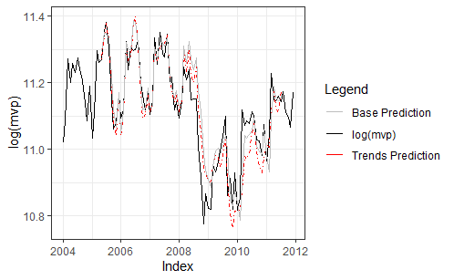

```r
prediction_data <-
  data.frame(base_prediction, trends_prediction) %>%
  na.omit(base_prediction) %>%
  mutate(row_num = row_number() + 16)

total <-
  combined_retail_auto_trends %>%
  left_join(prediction_data, by = "row_num")

pred_colors = c("Trends Prediction" = "red", "Base Prediction" = "grey", "log(mvp)"= "black")
ggplot(total, aes(x = ymd, y = log_sales)) +
  geom_line(aes(color = "log(mvp)")) +
  geom_line(aes(y = trends_prediction, color = "Trends Prediction"), linetype = "dotdash") +
  geom_line(aes(y = base_prediction, color="Base Prediction")) +
  labs(x='Index',
       y='log(mvp)',
       color="Legend") +
  scale_color_manual(values = pred_colors) +
  scale_y_continuous()
```

```r
NA
NA
NA
```

Can we calculate the RMSE of the model?

```r
rmse(simple_model, combined_retail_auto)
```

```
[1] 4442.593
```

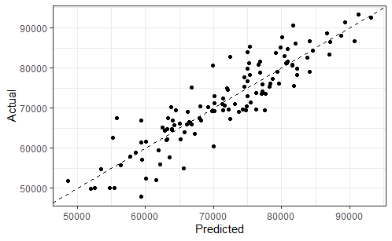

```r
combined_retail_auto <-
  combined_retail_auto %>%
  add_predictions(simple_model)


# Let's plot how the model does with predictions and the actual value
combined_retail_auto %>%
  ggplot(aes(x=pred, y=Value)) +
  geom_point() +
  geom_abline(linetype = "dashed") +
  xlab("Predicted") +
  ylab("Actual")
```

For this simple model, the RMSE is 4442.593 and plotting the predicted with the actual value shows a diagonal prediction line running through the data. Which indicates that the model is predicting well. However, does it improve MAE compared to the trends data?

Now to compare MAE

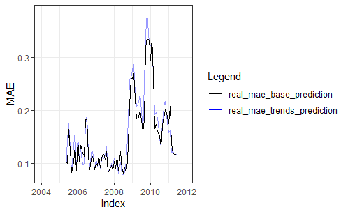

```r
real_mae_data <- data.frame(real_mae_base_prediction, real_mae_trends_prediction) %>%
  na.omit(real_mae_base_prediction) %>%
  mutate(row_num = row_number() + 16)

real_mae_total <-
  combined_retail_auto_trends %>%
  left_join(real_mae_data, by = "row_num")

colors <- c("real_mae_trends_prediction" = "blue", "real_mae_base_prediction" = "black")

ggplot(real_mae_total, aes(x = ymd, y = real_mae_base_prediction)) +
  geom_line() +
  geom_line(aes(y = real_mae_trends_prediction, color = "real_mae_trends_prediction"), alpha= 0.4) +
  geom_line(aes(y = real_mae_base_prediction, color="real_mae_base_prediction")) +
  labs(x= 'Index', y ='MAE',color = "Legend") +
  scale_color_manual(values=colors) +
  scale_y_continuous()
```

After our initial investigation in only adding the retail sales along with auto sales lags of 1 month and one year, our model does not seem to be performing better. However, this is not a strong model as it does not account for most of the auto related data that the census has to offer. We can continue this with more relevant auto related Census data.

### Increasing Focus After Initial Investigation and Adding More Relevant Features from Census Data

Now gathering more datasets from the census including all auto sales and gas prices

```r
# census data for the autos
base_mvp <- read.csv("real_base_autos.csv") %>%
  rename("Sales" = Value) %>%
  mutate(ymd2 = paste(Period, "-01", sep="")) %>%
  mutate(ymd = as.Date(ymd2, "%b-%y-%d")) %>% select(ymd, Sales)


autos <- read.csv("auto_and_other_motor_vehicles.csv") %>%
  rename("Autos" = Value) %>%
  mutate(ymd2 = paste(Period, "-01", sep="")) %>%
  mutate(ymd = as.Date(ymd2, "%b-%Y-%d")) %>% select(ymd, Autos)

gas <- read.csv("gas_stations.csv") %>%
  rename("Gas" = Value) %>%
  mutate(ymd2 = paste(Period, "-01", sep="")) %>%
  mutate(ymd = as.Date(ymd2, "%b-%Y-%d")) %>% select(ymd, Gas)

mvp <- left_join(autos, base_mvp, by = "ymd") %>%
  left_join(real_base_retail, by = "ymd") %>%
  left_join(gas, base_mvp, by = "ymd") %>%
  mutate(last_month = lag(Sales), last_year = lag(Sales, 12)) %>%
  mutate(row_num = row_number()) %>%
  mutate(log_sales = log(Sales)) %>% #include the lags
  mutate(last_month_gas = lag(Gas, 1)) %>%
  mutate(last_year_gas = lag(Gas, 12)) %>%
  mutate(last_month_auto = lag(Autos, 1)) %>%
  mutate(last_year_auto = lag(Autos, 12)) %>%
  mutate(last_month_retail = lag(Retail, 1)) %>%
  mutate(last_year_retail = lag(Retail, 12)) %>%
  filter(ymd < "2012-01-01")
```

```r
model_02 <- lm(Sales ~ last_month + last_year + last_month_auto + last_year_auto +  last_month_gas + last_year_gas + last_month_retail + last_year_retail ,  data=combined)

summary(model_02)
```

```
Call:
lm(formula = Sales ~ last_month + last_year + last_month_auto +
    last_year_auto + last_month_gas + last_year_gas + last_month_retail +
    last_year_retail, data = combined)

Residuals:
     Min       1Q   Median       3Q      Max
-11031.9  -2770.6    537.1   2929.0   6899.9

Coefficients:
                    Estimate Std. Error t value Pr(>|t|)
(Intercept)       -3.036e+03  1.139e+04  -0.267  0.79057
last_month        -4.491e+00  1.761e+00  -2.550  0.01281
last_year          8.156e+00  1.747e+00   4.668 1.30e-05
last_month_auto    5.375e+00  1.805e+00   2.978  0.00391
last_year_auto    -8.081e+00  1.754e+00  -4.607 1.64e-05
last_month_gas    -8.551e-02  1.280e-01  -0.668  0.50624
last_year_gas     -4.312e-01  1.345e-01  -3.205  0.00198
last_month_retail -3.910e-02  2.593e-02  -1.508  0.13568
last_year_retail   6.674e-02  2.400e-02   2.780  0.00686

(Intercept)
last_month        *
last_year         ***
last_month_auto   **
last_year_auto    ***
last_month_gas
last_year_gas     **
last_month_retail
last_year_retail  **
---
Signif. codes:
0 ‘***’ 0.001 ‘**’ 0.01 ‘*’ 0.05 ‘.’ 0.1 ‘ ’ 1

Residual standard error: 4130 on 75 degrees of freedom
  (12 observations deleted due to missingness)
Multiple R-squared:  0.8345,    Adjusted R-squared:  0.8169
F-statistic: 47.28 on 8 and 75 DF,  p-value: < 2.2e-16
```

We chart this to see how this model with more indicators does compared to the trends data and the actual data

```r
base_prediction = c()
trends_prediction = c()
mae_base_prediction = c()
mae_trends_prediction = c()

# create a combined dataset for real trends data and real census data
combined <-
  mvp %>%
  left_join(real_trends_mvp, by="ymd") %>%
  filter(ymd < "2012-01-01")


K <- 17: nrow(mvp) # dates

for (k in K) {
  test_data<- combined %>% filter(row_num <= k) # only uses previous data
  model_base <- lm(log_sales ~ last_month + last_year + last_month_auto + last_year_auto +  last_month_gas + last_year_gas + last_month_retail + last_year_retail, data=test_data)
  model_trends <- lm(log_sales ~ last_month + last_year + suvs + insurance, data=test_data)

  base_prediction[k] <- predict(model_base, test_data)[k]
  trends_prediction[k] <- predict(model_trends, test_data)[k]

  # calculate mae for trends and baseline
  mae_base_prediction[k] <- mean(abs(predict(model_base, test_data)[k] - test_data$log_sales))
# calculate mae for trends and baseline
  mae_trends_prediction[k] <- mean(abs(predict(model_trends, test_data)[k] - test_data$log_sales))

}
```

[output not shown]

Now let’s graph it again to see if there is a difference

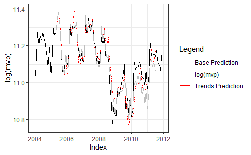

```r
prediction_data <-
  data.frame(base_prediction, trends_prediction) %>%
  na.omit(base_prediction) %>%
  mutate(row_num = row_number() + 16)

total <-
  combined %>%
  left_join(prediction_data, by = "row_num")

pred_colors = c("Trends Prediction" = "red", "Base Prediction" = "grey", "log(mvp)"= "black")
ggplot(total, aes(x = ymd, y = log_sales)) +
  geom_line(aes(color = "log(mvp)")) +
  geom_line(aes(y = trends_prediction, color = "Trends Prediction"), linetype = "dotdash") +
  geom_line(aes(y = base_prediction, color="Base Prediction")) +
  labs(x='Index',
       y='log(mvp)',
       color="Legend") +
  scale_color_manual(values = pred_colors) +
  scale_y_continuous()
```

```r
NA
NA
```

Checking the summary of the model:

```r
rmse(model_02, mvp)
```

```
[1] 3902.857
```

```r
summary(model_02)
```

```
Call:
lm(formula = Sales ~ last_month + last_year + last_month_auto +
    last_year_auto + last_month_gas + last_year_gas + last_month_retail +
    last_year_retail, data = combined)

Residuals:
     Min       1Q   Median       3Q      Max
-11031.9  -2770.6    537.1   2929.0   6899.9

Coefficients:
                    Estimate Std. Error t value Pr(>|t|)
(Intercept)       -3.036e+03  1.139e+04  -0.267  0.79057
last_month        -4.491e+00  1.761e+00  -2.550  0.01281
last_year          8.156e+00  1.747e+00   4.668 1.30e-05
last_month_auto    5.375e+00  1.805e+00   2.978  0.00391
last_year_auto    -8.081e+00  1.754e+00  -4.607 1.64e-05
last_month_gas    -8.551e-02  1.280e-01  -0.668  0.50624
last_year_gas     -4.312e-01  1.345e-01  -3.205  0.00198
last_month_retail -3.910e-02  2.593e-02  -1.508  0.13568
last_year_retail   6.674e-02  2.400e-02   2.780  0.00686

(Intercept)
last_month        *
last_year         ***
last_month_auto   **
last_year_auto    ***
last_month_gas
last_year_gas     **
last_month_retail
last_year_retail  **
---
Signif. codes:
0 ‘***’ 0.001 ‘**’ 0.01 ‘*’ 0.05 ‘.’ 0.1 ‘ ’ 1

Residual standard error: 4130 on 75 degrees of freedom
  (12 observations deleted due to missingness)
Multiple R-squared:  0.8345,    Adjusted R-squared:  0.8169
F-statistic: 47.28 on 8 and 75 DF,  p-value: < 2.2e-16
```

### Reducing the Number of Features - Can a simpler baseline model do even better?

Reducing the number of features on the baseline model may actually even improve performance as opposed to the trends data.

```r
model_03 <- lm(log_sales ~ last_month + last_year + last_month_auto + last_year_auto + last_month_gas + last_year_gas, data = combined)

summary(model_03)
```

```
Call:
lm(formula = log_sales ~ last_month + last_year + last_month_auto +
    last_year_auto + last_month_gas + last_year_gas, data = combined)

Residuals:
     Min       1Q   Median       3Q      Max
-0.17782 -0.04132  0.01047  0.04470  0.14610

Coefficients:
                  Estimate Std. Error t value Pr(>|t|)
(Intercept)      1.003e+01  1.399e-01  71.710  < 2e-16 ***
last_month      -5.809e-05  2.823e-05  -2.058  0.04298 *
last_year        1.371e-04  2.609e-05   5.253 1.29e-06 ***
last_month_auto  6.939e-05  2.890e-05   2.402  0.01874 *
last_year_auto  -1.342e-04  2.639e-05  -5.085 2.52e-06 ***
last_month_gas  -1.419e-06  1.888e-06  -0.752  0.45453
last_year_gas   -6.083e-06  2.136e-06  -2.848  0.00564 **
---
Signif. codes:
0 ‘***’ 0.001 ‘**’ 0.01 ‘*’ 0.05 ‘.’ 0.1 ‘ ’ 1

Residual standard error: 0.06793 on 77 degrees of freedom
  (12 observations deleted due to missingness)
Multiple R-squared:  0.7982,    Adjusted R-squared:  0.7824
F-statistic: 50.75 on 6 and 77 DF,  p-value: < 2.2e-16
```

```r
base_prediction
```

```
 [1]       NA       NA       NA       NA       NA       NA
 [7]       NA       NA       NA       NA       NA       NA
[13]       NA       NA       NA       NA 11.26865 11.35484
[19] 11.38179 11.30539 11.15533 11.08222 11.03764 11.17741
[25] 11.08212 11.08541 11.33235 11.29747 11.26787 11.32229
[31] 11.30445 11.32924 11.19685 11.18452 11.14231 11.19276
[37] 11.14238 11.14268 11.37256 11.27011 11.32906 11.31533
[43] 11.28230 11.33510 11.20658 11.20370 11.10590 11.11243
[49] 11.09312 11.10287 11.31265 11.22252 11.29032 11.19985
[55] 11.13979 11.16619 11.06383 11.05116 10.87136 10.90319
[61] 10.88036 10.91853 10.98496 10.94404 10.95552 10.95719
[67] 10.96408 11.00386 10.98566 10.86940 10.78736 10.90058
[73] 10.87274 10.88264 10.99191 11.02033 10.98548 11.05563
[79] 11.00659 11.03508 10.93037 10.96931 10.85037 10.90589
[85] 10.88841 10.94235 11.11998 11.12936 11.08446 11.12734
[91] 11.08387 11.14205 11.07416 11.06810 11.02862 11.03952
```

Comparing the MAE and the data fit we can see

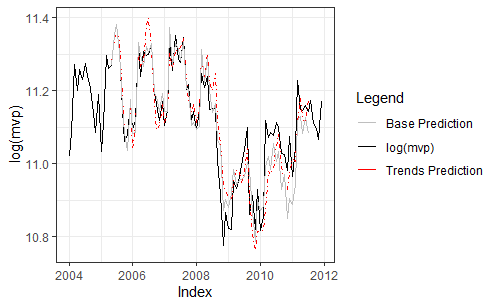

```r
# this combines the plot one next to the other
# par(mfrow = c(1,2))

prediction_data <-
  data.frame(base_prediction, trends_prediction) %>%
  na.omit(base_prediction) %>%
  mutate(row_num = row_number() + 16)

# this aligns the base and trend predictions with the original data we used to make the predictions
total <-
  combined %>%
  left_join(prediction_data, by = "row_num")

pred_colors = c("Trends Prediction" = "red", "Base Prediction" = "grey", "log(mvp)"= "black")
ggplot(total, aes(x = ymd, y = log_sales)) +
  geom_line(aes(color = "log(mvp)")) +
  geom_line(aes(y = trends_prediction, color = "Trends Prediction"), linetype = "dotdash") +
  geom_line(aes(y = base_prediction, color="Base Prediction")) +
  labs(x='Index',
       y='log(mvp)',
       color="Legend") +
  scale_color_manual(values = pred_colors) +
  scale_y_continuous()
```

Critiquing Choi and Varian’s Paper, comparing percentage change as improvement in MAE from base model to trends model gives a skewed representation of the significance of the change. Plotting the MAE of using the trends data and our new simple baseline model gives a better picture for comparison to the model’s performance.

[figure not shown]

```r
real_mae_data <-
  data.frame(real_mae_base_prediction, real_mae_trends_prediction) %>%
  na.omit(real_mae_base_prediction) %>%
  mutate(row_num = row_number() + 16)

real_mae_total <-
  combined %>%
  left_join(real_mae_data, by = "row_num")

colors <- c("real_mae_trends_prediction" = "blue", "real_mae_base_prediction" = "black")

ggplot(real_mae_total, aes(x = ymd, y = real_mae_base_prediction)) +
  geom_line() +
  geom_line(aes(y = real_mae_trends_prediction, color = "real_mae_trends_prediction"), alpha= 0.4) +
  geom_line(aes(y = real_mae_base_prediction, color="real_mae_base_prediction")) +
  labs(x= 'Index', y ='MAE',color = "Legend") +
  scale_color_manual(values=colors) +
  scale_y_continuous()
```

### Things to Note

From this graph, between the years 2005 to 2009, the base predictions that a similar or sometimes a little higher MAE. However, after 2009, the MAE for the baseline model is almost consistently lower than the trends prediction. But taking the average of the effect’s it would seem that the baseline is not doing significantly better than the trends data.

Let’s compare the average MAE for the trends model and the baseline model

```r
# for the baseline model
mean(mae_base_prediction, na.rm = T)
```

```
[1] 0.155271
```

```r
# for the trends model
mean(mae_trends_prediction, na.rm = T)
```

```
[1] 0.1572763
```

The average MAE for the trends model is very similar to the baseline model. One conclusion to draw from this could be that having a baseline of census data does not actually do better than taking search query intensity from Google Trends data.

However, it may also be that as with Choi and Varian, we are not employing effective enough features.

## Takeaway

However, we still draw the conclusion that a simple baseline model as this seems to perform about the same as the baseline model that Choi and Varian posed with the trends data. Pertaining to Choi and Varian’s trends model, even if the trends data is helpful, it is at best as good as more rigorous baseline models.

If expand on the using public data sets, I think we should keep in mind that the trends model was also very simple in terms of the search queries used, so beating that model with a ton more public data would not be a fair comparison on our side this time, we would be doing with baseline what we assess Choi and Varian did with trends. This can be disproved if there are other terms we can explore with the trends data that would do better than the baseline census model comparing similar features.

## Direction for Future Research

To extend this investigation further and further verify or deny the findings, we can look to see if this pattern holds using a model with trends data which has more closely related and relevant features for the baseline model using Census data and other public datasets. We can also investigate if these patterns hold over an extended period of time, for instance, up to the present and if any model does better, worse or the same. We could also try to see if we can extend our models to do forecasting instead of the “nowcasting” that the original authors suggest and peer into the future of auto sales.